# Application NutriScore

## Le pipeline de la donnée

### La lecture du csv

```
Chargement du csv dans un DataFrame
Nous avons gardé les 1000000 premières lignes du csv
Le DataFrame contient 187 colonnes
```

### Suppression les colonnes inutiles

Nos choix:

```
* Supprimer les colonnes vides
* Travailler sur les données quantitatives
* Uniquement les quantités pour 100g
* On garde la variable cible
```

Filtrage à l'aide d'une regex

```
On a supprimé 41 colonnes vides
On a supprimé 69 colonnes qualitatives
Notre DataFrame n'a plus que 79 colonnes
```

### Suppression des lignes inutiles

Nos choix:

```
* Supprimer les lignes vides
* Supprimer les lignes qui n'ont pas de variables explicatives
* Supprimer les doublons
```

Beaucoup de doublons, de nombreux produits avec des appellations différentes partagent des compositions identiques

```
132471  lignes vides supprimées
420765 enregistrements sans variable explicative
Il reste 94011 doublons
```

### Enregistrements qui partagent les mêmes valeurs sur les variables explicatives

|  | product_name |
| --- | --- |
| 547954 | Caramel breton au beurre sale |
| 754470 | Caramel au beurre salé |
| 754471 | Caramel au beurre salé au sel de guerande |
| 831135 | Boite sucettes caramel papillote |
| 831141 | Caramel au beurre salé au sel de Guérande |
| ... | ... |
| 999983 | Caramels tendres au beurre salé |
| 999986 | Caramel pain d’épice |
| 999989 | Caramel pain d'épices |
| 999991 | Caramel pain d’epices |
| 999993 | Caramel beurre sale |

101 rows × 1 columns

### Suppression des colonnes restantes incomplètes

Nos choix:

```
* supprimer les colonnes qui ont plus de 25% de valeurs manquantes
```

Le reste des colonnes seront complétées lors du preprocessing du pipeline du modèle

```
66 colonnes ont été supprimées
```

### Traitement des valeurs aberrantes

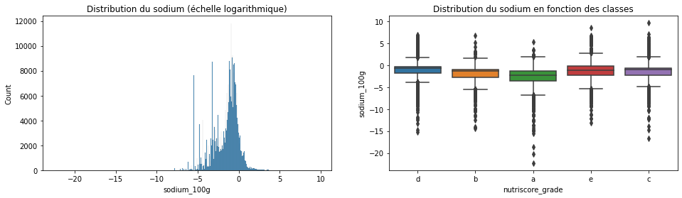

L'analyse graphique des boxplots et des distributions:

```
* La présence de valeurs aberrantes
* Certaines variables ne suivent pas une distribution gaussienne
* Les boxplots ne donnent pas d'informations sur l'explicabilité d'une variable
```

Une mise à l'échelle logarithmique peut faciliter la visualisation des distributions Le critère retenu se base sur l'IQR (InterQuartile Range), plus générale que le z-score

```
126654 lignes avec des valeurs aberrantes supprimées
```

### Analyser la pertinence des variables retenues

L'encodage de la variable cible permet de calculer ses corrélations:

```
* avec les variables explicatives importantes
* de supprimer les variables faiblement corrélées à la variable cible
```

Les corrélations permettent d'éliminer les variables explicatives qui fournissent les mêmes informations

```
* on supprime les variables qui sont trop fortement corrélées entre elles
```

On a supprimé les colonnes:

```
* fibres alimentaires, faiblement corrélées aux autres variables
* sodium trop liée au sel et ne figure pas sur les produits alimentaires
* nutriscores quantitatifs trop liés à la note nutriscore
```

## Préparation des données pour notre modèle

### Analyse de la répartition des modalités de la note nutriscore

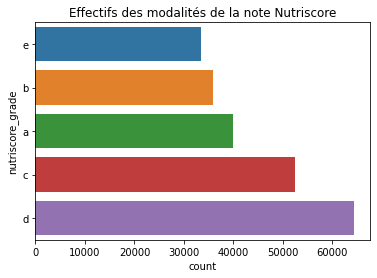

On choisit le down-sampling pour ne pas créer de nouvelles valeurs artificiellement:

```
* on garde les enregistrements de la modalité la moins représentée
* on choisit aléatoirement autant de valeurs pour les autres modalités
```

### Création des jeux de test et d'entraînement

On stratifie lors du split pour avoir une répartition équitables des modalités lors de l'entraîenement

## Création du pipeline

### Le pre-processing du pipeline

Le pre-processing comprend, le remplissage des valeurs manquantes:

```
* On remplit les valeurs manquantes avec le critère de la médiane, plus général que la moyenne
```

La mise à l'échelle des varibles explicatives:

```
* On choisit le critère du Min-Max, plus général que le centrage et la réduction
```

### Le choix du modèle

On teste 3 modèles:

```
* DecisionTreeClassifier
* RandomForestClassifier
* KNeighborsClassifier
```

On étudie l'effet d'un hyper-paramètre sur la qualité de l'entraînement:

```
* La profondeur de(s) arbre(s) pour DecisionTree et RandomForest
* Le nombre de voisins retenus pour KNeighbors
```

Les hyper-paramètres par défaut provoquent le sur-entraînement

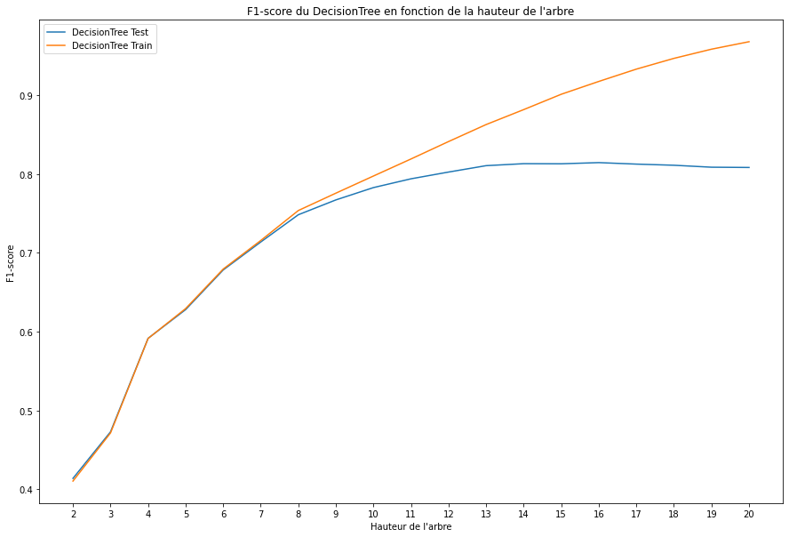

```
Une hauteur d'arbre entre 10 et 15 pour le DecisionTree
```

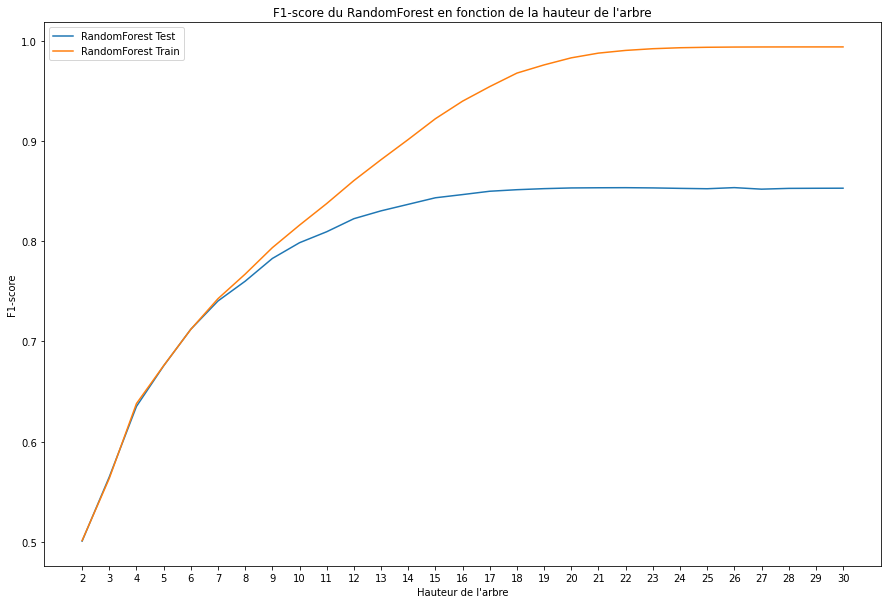

```
Une hauteur d'arbre entre 10 et 15 pour le RandomForest
```

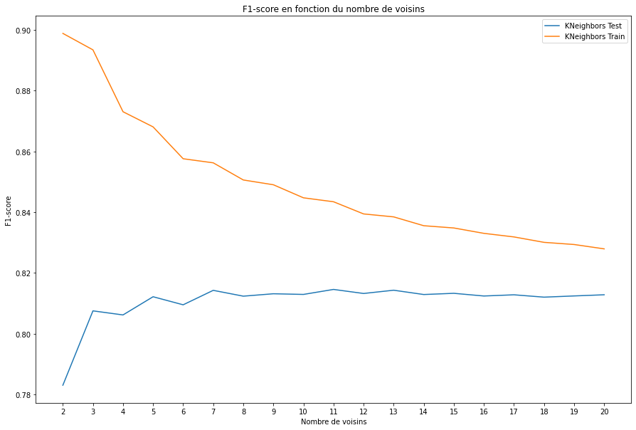

```
13 voisins plus proches pour le KNeighbors
```

```
* Il est moins facile d'interprétation
* Moins de contrôles sur des modèles complexes
```

Le RandomForest a été retenu:

```
* Plus facile à comprendre
* Meilleurs scores que le DecisionTree
```

Il faudrait tester l'ensemble des combinaisons d'hyper-paramètres, avec GridSearch

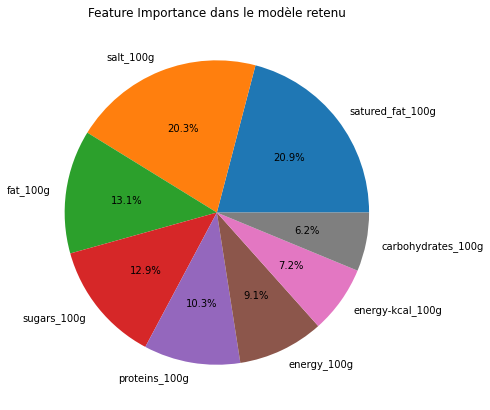

## Démonstration !

# Conclusion

Notre modèle reste perfectible:

```
* Erreurs de prédictions fréquentes
* Le modèle est coûteux en ressources
```

Pour l'améliorer nous pourrions mettre en place:

```
* Un questionnaire de satisfaction
* Alterner les modèles
* Combiner les modèles
```

Le retour de l'utilisateur permettra de ré-ajuster le modèle